# Análise de Regressão

João Ricardo F. de Lima

15 de Outubro de 2022.

# 1 Modelos de Regressão Simples

## 1.1 Definição do Modelo de Regressão Simples

O modelo de regressão simples pode ser usado para estudar a relação entre duas variáveis. Em outras palavras, quando se pretender analisar como “y” varia quando “x” mudar;

Considere duas variáveis “y” e “x” que representam alguma população. A equação abaixo relaciona as duas variáveis:

$$y=\beta_0+\beta_1x+u$$

A equação acima é válida para a população de interesse e chamada de **modelo de regressão linear simples**. Pode ser também chamada de regressão bivariada ou de duas variáveis.

Quando relacionadas como acima, as variáveis *x e* y* podem ser denominadas de diversas formas:

Tabela 1: Terminologia para a regressão simples:

| Y | X |
| --- | --- |
| Variável Dependente | Variável Independente |
| Variável Explicada | Variável Explicativa |
| Variável de Resposta | Variável de Controle |
| Variável Prevista | Variável Previsora |
| Regressando | Regressor |

O termo covariável também pode ser usado para x. O mais comum é variável dependente e independente.

Se os outros fatores são fixos, sua variação é zero, ou seja, $\Delta u=0$. Assim, x tem um efeito linear sobre y:

$$\Delta y=\beta_1 \Delta x \quad se \quad \Delta u=0$$

A variação em y é, simplesmente, $\beta_1$ multiplicado pela variação em x. Isso significa que $\beta_1$ é o **parâmetro de inclinação** da relação entre y e x, mantendo fixos os fatores em u;

O **parâmetro de intercepto** $\beta_0$ é chamado de constante do modelo.

O coeficiente de inclinação mede a taxa (parcial) da mudança no valor médio de y para uma mudança de uma unidade no valor da variável independente, tudo o mais constante;

O termo de erro **u** representa todas aquelas variáveis que não podem estar explícitas no modelo por razões diversas. Contudo, se assume que a influência destas sobre o regressando é insignificante;

Pode-se entender o termo de erro como os fatores não observados que afetam y.

## 1.2 Hipóteses do Modelo Clássico de Regressão Linear

Em relação ao termo de erro, é necessário fazer uma hipótese que restrinja a relação dele com a variável independente (x);

Como u e x são variáveis aleatórias, pode-se definir a distribuição condicional de u dado qualquer valor de x. A hipótese para se estimar um modelo de regressão com betas confiáveis é

$$E(u|x)=E(u)=0$$

O que está indicado na equação acima é que o valor médio de u é o mesmo para qualquer valor de x e igual a sua média aritmética. Em outras palavras, diz que u é **independente da média** de x.

Considerando o valor esperado da equação de Y em função de X e usando $E(u|x)=0$, se obtém:

$$E(y|x)=\beta_0+\beta_1x$$

A equação dada acima mostra que a **função de regressão populacional (FRP)**, $E(y|x)$, é uma função linear de x;

A linearidade significa que o aumento de uma unidade em x faz com que o valor esperado de y varie segundo a magnitude de $\beta_1$;

Para qualquer valor dado de x, a distribuição de y está centrada ao redor de $E(y|x)$.

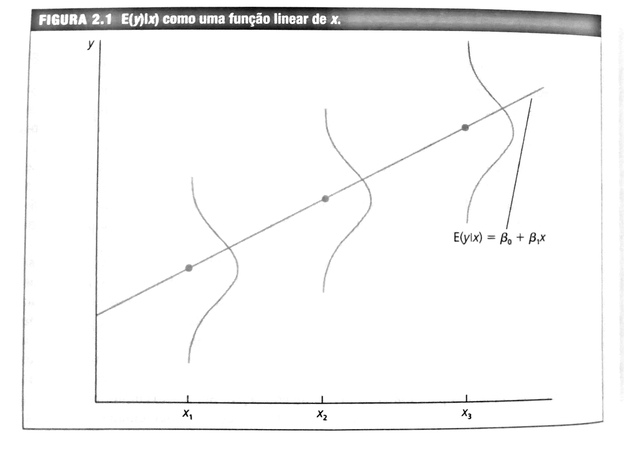

Modelo Clássico de Regressão Linear

Fonte: WOOLDRIDGE, 2017

## 1.3 Derivação das estimativas de Mínimos Quadrados Ordinários (MQO)

Para estimar o Modelo de Regressão Linear, ou seja, encontrar os parâmetros $\beta_0$ e $\beta_1$ da primeira equação acima o método mais usado é o dos Mínimos Quadrados Ordinários (MQO), pois é intuitivamente e matematicamente mais simples;

Dado que um Modelo de Regressão:

$$Y=\widehat{\beta}_0+\widehat{\beta}_1X+\widehat{u}$$

pode ser definido também como:

$$\widehat{Y}=\widehat{\beta}_0+\widehat{\beta}_1X$$

em que o “chápeu” sobre Y, os betas e u enfatiza que os valores são estimativas.

Pode-se reescrever de forma que:

$$Y=\widehat{Y}+\widehat{u}$$

ou ainda:

$$\widehat{u}=Y-\widehat{Y}$$

então, um método bom para se obter as estimativas dos $\beta$s seria fazer com que a soma de todos os erros fosse a menor possível;

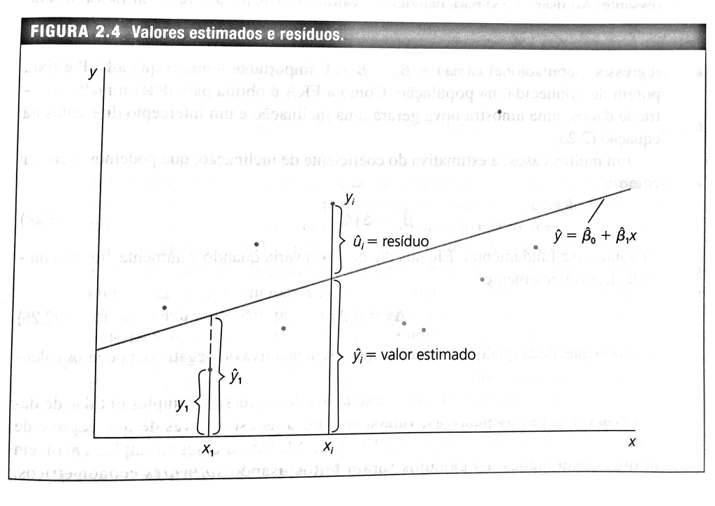

Modelo Clássico de Regressão Linear

Fonte: WOOLDRIDGE, 2017

Por questões teóricas, o método dos Mínimos Quadrados Ordinários (MQO) minimiza a soma dos erros ao quadrado, dando peso diferente às observações cujo valor estimado esteja mais próximo ou mais distante do valor observado ($Y$);

Assim, o que se precisa é minimizar uma função conhecida como Soma de Quadrados dos Resíduos (SQR):

$$min \sum\widehat{u}^2=\sum(Y-\widehat{\beta}_0-\widehat{\beta}_1X)^2$$

$$\frac{\partial\sum u^2}{\partial
\beta_0}=2\sum(Y-\hat{\beta_0}-\hat{\beta_1}X)(-1)=-2\sum(Y-\hat{\beta_0}-\hat{\beta_1}X)$$

$$\frac{\partial\sum u^2}{\partial
\beta_1}=2\sum(Y-\hat{\beta_0}-\hat{\beta_1}X)(-X)=-2\sum(Y-\hat{\beta_0}-\hat{\beta_1}X)(X)$$

Igualando as derivadas a zero, tem-se

$$-2\sum(Y-\hat{\beta_0}-\hat{\beta_1}X)=0$$

$$-2\sum(Y-\hat{\beta_0}-\hat{\beta_1}X)(X)=0$$

Se dividir tudo por -2N, tem-se

$$\frac{\sum(Y-\hat{\beta_0}-\hat{\beta_1}X)}{N}=0$$

$$\frac{\sum(Y-\hat{\beta_0}-\hat{\beta_1}X)(X)}{N}=0$$

Usando o operador do somatório tem-se:

$$\overline{Y}=\hat{\beta_0}+\hat{\beta_1}\overline{X}$$

$$\hat{\beta_0}=\overline{Y}-\hat{\beta_1}\overline{X}$$

Uma vez que se tenha $\hat{\beta_1}$, dados os valores das médias de Y e X se obtém o valor de $\hat{\beta_0}$.

Considerando a outra equação, mas suprimindo o N, que não afeta a solução, se pode obter:

$$\sum(Y-(\overline{Y}-\hat{\beta_1}\overline{X})-\hat{\beta_1}X)(X)=0$$

$$\sum(X)(Y-\overline{Y})=\sum(X)(-\hat{\beta_1}\overline{X})+\hat{\beta_1}X=0$$

Como $\hat{\beta_1}$ é uma constante e colocando em evidência:

$$\sum(X)(Y-\overline{Y})=\hat{\beta_1}\sum(X)(X-\overline{X})$$

Das propriedades do somatório, se tem que:

$$\sum(X)(Y-\overline{Y})=\sum(X-\overline{X})(Y-\overline{Y})$$

$$\sum(X)(X-\overline{X})=\sum(X-\overline{X})^2$$

Então, desde que $\sum(X-\overline{X})^2>0$, a inclinação estimada é

$$\hat{\beta_1}=\frac{\sum(X-\overline{X})(Y-\overline{Y})}{\sum(X-\overline{X})^2}$$

$$\hat{\beta_1}=\frac{\sum xy}{\sum x^2}$$

com $x=X-\overline{X}$ e $y=Y-\overline{Y}$.

A equação dada em acima é a covariância amostral de x e y dividida pela variância amostral de x. Podemos reescrever a forma de encontrar o $\hat{\beta}_1$ como abaixo:

$$\hat{\beta_1}=\frac{cov(xy)}{\hat{\sigma}_x \hat{\sigma}_x}\frac{\hat{\sigma}_y}{\hat{\sigma}_y}$$

$$\hat{\beta_1}=\frac{cov(xy)}{\hat{\sigma}_x
\hat{\sigma}_y}\frac{\hat{\sigma}_y}{\hat{\sigma}_x}$$

$$\hat{\beta_1}=\hat{\rho}_{xy}\frac{\hat{\sigma}_y}{\hat{\sigma}_x}$$

Em que $\hat{\rho}_{xy}$ é a correlação amostral entre x e y; e $\hat{\sigma}_y$ e $\hat{\sigma}_x$ são os desvios padrões amostrais. Se a correlação de x e y for positiva, $\hat\beta_1>0$ e se for negativa, $\hat\beta_1<0$.

Uma vez determinados os estimadores de intercepto e inclinação de MQO (Mínimos Quadrados Ordinários), se constrói a **reta de regressão de MQO**:

$$\hat{y}=\hat{\beta}_{0}+\hat{\beta}_{1}x$$

A função dada em acima é chamada de função de regressão amostral (FRA), pois ela é uma versão estimada da função de regressão populacional $E(y|x)=\beta_{0}+\beta_1x$.

Como a FRA é obtida para determinada amostra de dados, uma amostra diferente irá gerar um intercepto e um coeficiente de inclinação diferentes.

## 1.4 Exemplo da Regressão Simples

Com os dados de CEOSAL1, estimar a regressão entre salario anual em milhares de dólares (salary) de diretores executivos e retorno médio sobre o patrimônio líquido (roe), que é dado como uma % do patrimônio líquido.

## Exemplo no R

### Diretório e Carregamento dos pacotes

```r
#Verificando o diretorio que o R está direcionado
getwd()
```

```
## [1] "/Users/jricardofl/Dropbox/Embrapa/2022/PPGDIDES/Análise Multivariada/multivariada/regressao"
```

```r
#Limpa o Ambiente Global
rm(list=ls())

#Pode usar dados de outros softwares
library(wooldridge)
library(ggplot2)
library(dplyr)
library(rstatix)
library(htmltools)
library(knitr)
library(kableExtra)
library(tseries)
```

### Entrada dos dados

```r
data('ceosal1')

#Carregar dados no computador
ceosal1 <- ceosal1

#Observar a estrutura dos dados
glimpse(ceosal1)
```

```
## Rows: 209
## Columns: 12
## $ salary   <int> 1095, 1001, 1122, 578, 1368, 1145, 1078, 1094, 1237, 833, 567…
## $ pcsalary <int> 20, 32, 9, -9, 7, 5, 10, 7, 16, 5, 7, -3, -9, 9, 49, 4, 12, 9…
## $ sales    <dbl> 27595.0, 9958.0, 6125.9, 16246.0, 21783.2, 6021.4, 2266.7, 29…
## $ roe      <dbl> 14.1, 10.9, 23.5, 5.9, 13.8, 20.0, 16.4, 16.3, 10.5, 26.3, 25…
## $ pcroe    <dbl> 106.4, -30.6, -16.3, -25.7, -3.0, 1.0, -5.9, -1.6, -70.2, -23…
## $ ros      <int> 191, 13, 14, -21, 56, 55, 62, 44, 37, 37, 109, -10, 41, 44, 6…
## $ indus    <int> 1, 1, 1, 1, 1, 1, 1, 1, 1, 1, 1, 1, 1, 1, 1, 1, 1, 1, 1, 1, 1…
## $ finance  <int> 0, 0, 0, 0, 0, 0, 0, 0, 0, 0, 0, 0, 0, 0, 0, 0, 0, 0, 0, 0, 0…
## $ consprod <int> 0, 0, 0, 0, 0, 0, 0, 0, 0, 0, 0, 0, 0, 0, 0, 0, 0, 0, 0, 0, 0…
## $ utility  <int> 0, 0, 0, 0, 0, 0, 0, 0, 0, 0, 0, 0, 0, 0, 0, 0, 0, 0, 0, 0, 0…
## $ lsalary  <dbl> 6.998509, 6.908755, 7.022868, 6.359574, 7.221105, 7.043160, 6…
## $ lsales   <dbl> 10.225389, 9.206132, 8.720281, 9.695602, 9.988894, 8.703075, …
```

```r
attach(ceosal1)
```

### Estatística Descritiva

A primeira análise é sobre as estatísticas descritivas das duas variáveis.

```r
#Estatistica Descritiva dos Dados
summary(salary)
```

```
##    Min. 1st Qu.  Median    Mean 3rd Qu.    Max.
##     223     736    1039    1281    1407   14822
```

```r
summary(roe)
```

```
##    Min. 1st Qu.  Median    Mean 3rd Qu.    Max.
##    0.50   12.40   15.50   17.18   20.00   56.30
```

### Estimação do Modelo

Em seguida, a análise de regressão simples:

```r
#Estimar a regressao com intercepto
regressao1 <- lm(salary ~ roe, data=ceosal1)

#Resultados da Regressao
summary(regressao1)
```

```
##
## Call:
## lm(formula = salary ~ roe, data = ceosal1)
##
## Residuals:
##     Min      1Q  Median      3Q     Max
## -1160.2  -526.0  -254.0   138.8 13499.9
##
## Coefficients:
##             Estimate Std. Error t value Pr(>|t|)
## (Intercept)   963.19     213.24   4.517 1.05e-05 ***
## roe            18.50      11.12   1.663   0.0978 .
## ---
## Signif. codes:  0 '***' 0.001 '**' 0.01 '*' 0.05 '.' 0.1 ' ' 1
##
## Residual standard error: 1367 on 207 degrees of freedom
## Multiple R-squared:  0.01319,    Adjusted R-squared:  0.008421
## F-statistic: 2.767 on 1 and 207 DF,  p-value: 0.09777
```

### Gráfico do Modelo Estimado

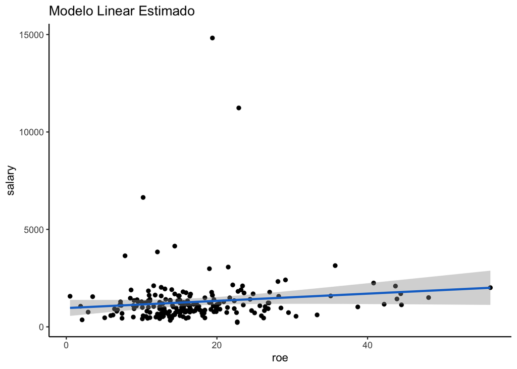

```r
g1 <- ggplot(data = ceosal1, aes(x = roe, y = salary)) +
  geom_point() +
  stat_smooth(method = "lm", col = "dodgerblue3") +
  theme(panel.background = element_rect(fill = "white"),
        axis.line.x=element_line(),
        axis.line.y=element_line()) +
  ggtitle("Modelo Linear Estimado")

g1
```

### Fazer previsão com base no modelo estimado

Com base no modelo estimado é possível fazer previsões. Se $roe=30$, quanto seria o salário estimado?

```r
predict(regressao1, data.frame(roe = 30))
```

```
##        1
## 1518.227
```

# 2 Variância e Erros-padrão dos estimadores de MQO

Os $\beta$s estimados por MQO são variáveis aleatórias, dado que seus valores variam entre amostras. Portanto, é necessário mensurar sua variabilidade. Para isto, se usa a variância ($S^2$).

$$var(\hat{\beta_0})=S^2(\hat{\beta_0})=\frac{\hat{\sigma}^2\sum X_i^2}{n
\sum x_i^2}$$

com $\sum x_i^2=\sum (X-\bar X)^2$

$$var(\hat{\beta_1})=S^2(\hat{\beta_1})=\frac{\hat{\sigma}^2}{\sum x_i^2}$$

Para o Modelo de Regressão Linear, uma estimativa da variância do termo de erro $u_i$, é obtida por:

$$\hat{\sigma}^2=\frac{\sum{\hat{u_i}^2}}{n-k}=\frac{SQR}{n-k}$$

em que $n$=tamanho da amostra e k=número de $\beta$’s estimados.

$\hat{\sigma}=\sqrt{\hat{\sigma}^2}$ é denominado de erro padrão da regressão.

Se o erro-padrão da variável dependente Y ($S_y$) for menor do que o erro padrão da regressão, a regressão não tem sentido, dado que os $X$’s nao tem impacto sobre $Y$. A melhor estimativa de Y, no caso de $S_y < \hat{\sigma}^2$, é a média de Y, ou seja, $\bar{Y}$.

No caso do erro-padrão ($S$), se tem:

$$S(\hat{\beta_0})=\sqrt{S^2(\hat{\beta_0})}=\sqrt{\frac{\hat{\sigma}^2\sum
X_i^2}{n \sum x_i^2}}$$
com $\sum x_i^2=\sum (X-\bar X)^2$

$$S(\hat{\beta_1})=\sqrt{S^2(\hat{\beta_1})}=\sqrt{\frac{\hat{\sigma}^2}{\sum
x_i^2}}$$

# 3 Teste de Hipóteses

Suponha que queiramos testar se o coeficiente da regressão $\beta_k=0$. Para testar isso, deve ser usado o teste t dado por:

$$t=\frac{\hat{\beta_k}-\beta_k}{S(\hat{\beta_k)}} \sim t(n-k)gl$$

Em que $S(\hat{\beta})$ é o erro padrão do $\beta$ que está sendo testado. Se $t(calc) > t(tab)$, pode-se rejeitar a hipótese nula de que $\beta_k=0$.

Neste caso, se diz que o $\beta$ é significativo, ou seja, significativamente diferente de zero. Os valores de probabilidade escolhidos mais comumente são 10%, 5% e 1%.

Estes valores são chamados como níveis de significância também conhecidos como erro Tipo I (probabilidade de rejeitar $H_0$, quando $H_0$ é verdadeiro). Os softwares econometricos já reportam automaticamente, não apenas os valores do teste t calculado, como os valores de probabilidade (p-value), que são os níveis exatos de significância dos valores de t.

Na prática, um p-value abaixo de 0,10 sugere que o coeficiente estimado é estatisticamente significativo.

# 4 Valores estimados e resíduos

Após obter as estimativas de $\beta_0$ (intercepto) e de $\beta_1$ (coeficiente de inclinação), em uma amostra específica, é possível obter o valor estimado $\hat{y}$ para cada observação “i”.

$$\hat{y}_i=\hat{\beta}_0+\hat{\beta}_1x_i$$

Por definição, cada valor estimado está sobre a reta de regressão obtida por MQO. O resíduo associado a cada observação “$u_i$” é a diferença entre o valor observado $y_i$ e o estimado.

$$\hat{u}_i=y_i-\hat{y}_i$$

Se “$u_i$” for positivo, a reta subestima $y_i$. Se for negativo, superestima. Se $u_i=0$, o previsto é igual ao observado, mas isso raramente ocorre.

## 4.1 Demonstração no R

### 4.1.1 Estimação do Modelo e Geração dos Valores Previstos e Resíduos

```r
# Estimação do Modelo
regressao1 <- lm(salary ~ roe, data=ceosal1)

#Resultados da Regressao
summary(regressao1)
```

```
##
## Call:
## lm(formula = salary ~ roe, data = ceosal1)
##
## Residuals:
##     Min      1Q  Median      3Q     Max
## -1160.2  -526.0  -254.0   138.8 13499.9
##
## Coefficients:
##             Estimate Std. Error t value Pr(>|t|)
## (Intercept)   963.19     213.24   4.517 1.05e-05 ***
## roe            18.50      11.12   1.663   0.0978 .
## ---
## Signif. codes:  0 '***' 0.001 '**' 0.01 '*' 0.05 '.' 0.1 ' ' 1
##
## Residual standard error: 1367 on 207 degrees of freedom
## Multiple R-squared:  0.01319,    Adjusted R-squared:  0.008421
## F-statistic: 2.767 on 1 and 207 DF,  p-value: 0.09777
```

```r
#Valores previstos pelo modelo
salaryhat <- predict(regressao1)

# Resíduos estimados
uhat <- regressao1$residuals
```

### 4.1.2 Visualização dos Dados

```r
#Junção dos dados
dados <- ceosal1%>%
  select(c(salary, roe))

dados$salaryhat <- round(salaryhat,2)
dados$uhat <- round(uhat,2)

#Tabela com os dados
kable(head(dados, 10), align='cccc') %>%
  kable_styling(full_width=TRUE, position = "center")
```

| salary | roe | salaryhat | uhat |
| --- | --- | --- | --- |
| 1095 | 14.1 | 1224.06 | -129.06 |
| 1001 | 10.9 | 1164.85 | -163.85 |
| 1122 | 23.5 | 1397.97 | -275.97 |
| 578 | 5.9 | 1072.35 | -494.35 |
| 1368 | 13.8 | 1218.51 | 149.49 |
| 1145 | 20.0 | 1333.22 | -188.22 |
| 1078 | 16.4 | 1266.61 | -188.61 |
| 1094 | 16.3 | 1264.76 | -170.76 |
| 1237 | 10.5 | 1157.45 | 79.55 |
| 833 | 26.3 | 1449.77 | -616.77 |

# 5 Propriedades Algébricas das estatísticas de MQO

Há várias propriedades algébricas úteis das estimativas de MQO e das estatísticas a elas associadas:

$$\sum_{i=1}^{n}\hat{u}_i=0$$

Esta propriedade deriva da condição de primeira ordem feita para se encontrar os betas por MQO. Em outras palavras, os desvios da linha da regressão somam zero.

A Covariância amostral entre os regressores (variável independente) e os resíduos é zero:

$$\sum_{i=1}^{n}x_i\hat{u}_i=0$$

O ponto $(\bar{x}, \bar{y})$ sempre está sobre a reta de regressão.

$$\bar{y}=\hat{\beta}_0+\hat{\beta}_1\bar{x}$$

Se $\bar{x}$ for inserido no lugar de x, o valor ajustado é $\bar{y}$.

# 6 Qualidade do Ajustamento da Regressão

## 6.1 Coeficiente de determinação - $R^2$

Depois da estimação do modelo é fundamental que se observe o quão bem a variável independente explica a variável dependente, ou seja, a qualidade de ajustamento. O Coeficiente de Determinação $(R^2)$ é uma medida da qualidade do ajustamento do modelo. Ele fornece o percentual da variação total da variável dependente que é explicada pelo conjunto das variáveis independentes.

Para calcular o $R^2$, é necessário definir:

1. Soma de Quadrado Total $=\sum(Y-\bar Y)^2=\sum y^2$
2. Soma de Quadrado Explicada $=\sum (\hat Y-\bar Y)^2$
3. Soma de Quadrado do Resíduo $=\sum (Y- \hat Y)^2=\sum u^2$

com $SQT=SQE+SQR$.

Tabela 1: Quadro da Análise de Variância - ANOVA

| Fonte | Soma de Quadrados | G.L. | Quadrado Médio |
| --- | --- | --- | --- |
| Regressão | SQE | p | SQE/P |
| Resíduo | SQR | n-p-1 | SQR/n-p-1 |
| Total | SQT | n-1 |  |

Considerando que $SQT=SQE+SQR$, se dividir tudo por SQT, temos:

$$\frac {SQT}{SQT}=\frac {SQE}{SQT}+ \frac {SQR}{SQT}$$
$$1=R^2+ \frac {SQR}{SQT}$$

$$R^2=1- \frac {SQR}{SQT}$$
sendo o coeficiente de determinação $R^2$ definido por $\frac{SQE}{SQT}$

São duas alternativas para escrever o $R^2$. O coeficiente de determinação varia entre 0 e 1. Quanto mais próximo de 1, melhor a qualidade do ajuste do modelo.

O $R^2$ possui algumas desvantagens, pois é uma função crescente do número de variáveis explicativas. Quanto maior o número de regressores, maior o $R^2$.

Pode ser mostrado que o $R^2$ é igual ao quadrado do coeficiente de correlação amostral entre $y_i$ e $\hat{y}_i$.

Para escolher, entre 2 modelos, qual possui o melhor ajuste, quando possuem quantidades diferentes de regressores, deve-se usar o $R^2$ ajustado, denotado por $\bar R^2$.

O $\bar R^2$ impõe uma “penalidade” por se adicionar mais regressores.

Se $k$, o número de regressores, é $> 1$, necessariamente $\bar R^2 < R^2$

$$\bar R^2=1-(1-R^2) \frac {n-1}{n-k}$$

Tanto o $R^2$ quanto o $\bar R^2$ servem para comparar diferentes modelos que possuam a mesma variável dependente.

Na equação que estamos usando como exemplo, apenas 1,319% da variação de Salary é explicado pelo ROE:

$$\widehat{salary}=963,19+18,50roe$$
$$n=209, \quad
R^2=0,01319$$

```r
#Resultados da Regressao
summary(regressao1)
```

```
##
## Call:
## lm(formula = salary ~ roe, data = ceosal1)
##
## Residuals:
##     Min      1Q  Median      3Q     Max
## -1160.2  -526.0  -254.0   138.8 13499.9
##
## Coefficients:
##             Estimate Std. Error t value Pr(>|t|)
## (Intercept)   963.19     213.24   4.517 1.05e-05 ***
## roe            18.50      11.12   1.663   0.0978 .
## ---
## Signif. codes:  0 '***' 0.001 '**' 0.01 '*' 0.05 '.' 0.1 ' ' 1
##
## Residual standard error: 1367 on 207 degrees of freedom
## Multiple R-squared:  0.01319,    Adjusted R-squared:  0.008421
## F-statistic: 2.767 on 1 and 207 DF,  p-value: 0.09777
```

# 7 Intervalo de Confiança

Alguns softwares (como o R), calculam um intervalo de confiança para cada coeficiente estimado da regressão.

Um intervalo de confiança para um $\beta_k$ qualquer é dado por

$$\begin{equation}
Pr[\beta_k \pm t_\alpha/_2 ep(\beta_k)]=(1-\alpha)
\tag{1}
\end{equation}$$

com $\alpha$ sendo o nível de significância, Pr a probabilidade e $t_\alpha/_2$ o valor da estatística t obtido na tabela t de Student e $ep(\beta_k)$ o erro padrão de $\beta_k$.

## 7.1 Demonstração no R - Intervalo de Confiança

```r
# Estimação do Modelo
regressao1 <- lm(salary ~ roe, data=ceosal1)

#Resultados da Regressao
summary(regressao1)
```

```
##
## Call:
## lm(formula = salary ~ roe, data = ceosal1)
##
## Residuals:
##     Min      1Q  Median      3Q     Max
## -1160.2  -526.0  -254.0   138.8 13499.9
##
## Coefficients:
##             Estimate Std. Error t value Pr(>|t|)
## (Intercept)   963.19     213.24   4.517 1.05e-05 ***
## roe            18.50      11.12   1.663   0.0978 .
## ---
## Signif. codes:  0 '***' 0.001 '**' 0.01 '*' 0.05 '.' 0.1 ' ' 1
##
## Residual standard error: 1367 on 207 degrees of freedom
## Multiple R-squared:  0.01319,    Adjusted R-squared:  0.008421
## F-statistic: 2.767 on 1 and 207 DF,  p-value: 0.09777
```

```r
#Quadro da Anova
anova(regressao1)
```

```
## Analysis of Variance Table
##
## Response: salary
##            Df    Sum Sq Mean Sq F value  Pr(>F)
## roe         1   5166419 5166419  2.7665 0.09777 .
## Residuals 207 386566563 1867471
## ---
## Signif. codes:  0 '***' 0.001 '**' 0.01 '*' 0.05 '.' 0.1 ' ' 1
```

```r
#Intervalo de Confiança
confint(regressao1)
```

```
##                  2.5 %     97.5 %
## (Intercept) 542.790219 1383.59245
## roe          -3.428196   40.43057
```

A interpretação diz que se estimarmos esta equação 100 vezes, em 95 delas o valor da estimativa do ROE estará entre -3.428196 e 40.43057.

```r
#Intervalo de confiança dos betas estimados

# Valor do t com alfa/2
qt(.975, df=207)
```

```
## [1] 1.97149
```

```r
(18.50)-11.12*1.97149
```

```
## [1] -3.422969
```

```r
(18.50)+11.12*1.97149
```

```
## [1] 40.42297
```

# 8 Pressupostos do Modelo Clássico de Regressão Linear

O Modelo Clássico de Regressão Linear se baseia em algumas hipóteses:

1. O modelo de regressão é linear nos parâmetros;
2. Os regressores são fixos (não aleatórios) em amostras repetidas (análise de regressão é condicional aos valores de X, ou seja, $E(Y|X)$;
3. Dados os valores de X, $E(u|X)=0$;

Com isso, é possível demonstrar que o estimador de MQO não é viesado: $E(\hat{\beta}_0)=\beta_0$ e $E(\hat{\beta}_1)=\beta_1$.

**Intepretação de não viesado**

Os coeficientes estimados podem ser menores ou maiores, dependendo da amostra que é o resultado de um sorteio aleatório.

No entanto, em média, eles serão iguais aos valores que caracterizam a verdadeira relação entre y e x na população.

“Em média” significa que, a amostragem foi repetida, ou seja, foram sorteadas amostras aleatórias e repetidas as estimações diversas vezes.

Em uma dada amostra, as estimativas podem diferir consideravelmente dos valores verdadeiros. A demonstração será feita na parte de regressão múltipla.

Continuando com as hipóteses do MCRL, além de saber que a distribuição amostral de $\hat{\beta}_1$ está centrada em torno de $\beta_1$, é importante saber o quão distante, em média, pode-se esperar que $\hat{\beta}_1$ esteja de $\beta_1$:

4. A variância de cada observação $u$, dados os valores de X, é constante - *homocedástico*:

$$\begin{equation}
var (u|x)=\sigma^2
\tag{2}
\end{equation}$$

O valor da variável independente não deve conter informação sobre a variabilidade dos fatores não observados.

Como $var(u|x)=E(u^2|x)-[E(u|x)]^2$ e $E(u|x)=0$, $\sigma^2=E(u^2|x)$.

Portanto, $\sigma^2=E(u^2)=var(u)$, pois $E(u)=0$.

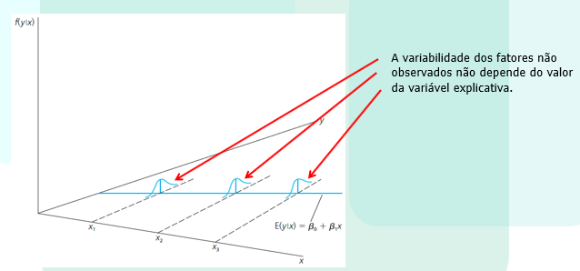

Homocedasticidade

Fonte: Wooldridge, 2017.

Outras hipóteses do MCRL:

5. Não há autocorrelação entre os termos de erro.

$$\begin{equation}
cov (u_i,u_j|X)=0
\tag{3}
\end{equation}$$

6. Nao existe multicolinearidade perfeita;
7. O modelo está corretamente especificado;
8. Os resíduos seguem a distribuição :

$$\begin{equation}
u \sim N(0,\sigma^2)
\tag{4}
\end{equation}$$

# 9 Normalidade dos Resíduos

O MCRL assume que cada $u_i$ é distribuído Normalmente com:

**Média Zero**

$$E(u_i)=0$$
**Variância Constante**

$$E[u_i-E(u_i)]^2=E(u_i^2)= \sigma^2$$

**Covariância Zero**

$$E{[(u_i-E(u_i)][u_j-E(u_j)]}=E(u_i,u_j) =0 \quad \forall \quad i\neq j$$

ou dito de outra forma

$$\begin{equation}
u_i \sim N(0,\sigma^2)
\tag{5}
\end{equation}$$

se duas variáveis são normalmente distribuídas e não são autocorrelacionadas, são chamadas de independentes. Assim, pode-se reescrever (5) da seguinte forma:

$$\begin{equation}
u_i \sim IID(0,\sigma^2)
\tag{6}
\end{equation}$$

## 9.1 Teste de Normalidade de Jarque-Bera

Para se testar Normalidade dos resíduos pode-se fazer um histograma dos resíduos e observar seu comportamento ou fazer o **teste de Jarque-Bera (JB)** de Normalidade dos resíduos. O teste de Jarque-Bera tem como pressuposto que a amostra seja grande.

O teste calcula a simetria da distribuição dos resíduos e a Curtose e usa a seguintes estatística de teste:

$$\begin{equation}
JB=n [\frac{S^2}{6}+ \frac{(K-3)^2}{24}]
\tag{7}
\end{equation}$$

que segue a distribuição de $\chi^2$ com 2 graus de liberdade. A **hipótese nula** do teste de JB é que *os resíduos seguem a distribuição Normal*.

### 9.1.1 Exemplo no R

```r
# Estimação do Modelo
regressao1 <- lm(salary ~ roe, data=ceosal1)

#Teste de Normalidade de Jarque-Bera - precisa do pacote tseries
jarque.bera.test(regressao1$residuals)
```

```
##
##  Jarque Bera Test
##
## data:  regressao1$residuals
## X-squared = 31121, df = 2, p-value < 2.2e-16
```

Como o valor de probabilidade é menor do que 0,10, rejeitamos a hipótese nula, ou seja, os resíduos não seguem a distribuição Normal.

## 9.2 Teste de Normalidade de Shapiro-Wilk

O teste de Shapiro-Wilk é um teste de normalidade que testa, com base na estatística W, se um conjunto de dados segue a distribuição Normal. A estatística é:

$$\begin{equation}
W=\frac{(\sum_{i=1}^{n}a_ix_i)^2}{(\sum_{i=1}^{n}x_i-\bar{x})^2}
\tag{8}
\end{equation}$$

Em que $x_i$ o menor número da amostra; $\bar{x}$ é a média amostral; as constantes $a_i$ são constantes geradas pelas médias, variâncias e covariâncias das estatísticas de ordem de uma amostra de tamanho n de uma distribuição Normal.

### 9.2.1 Exemplo no R

```r
# Estimação do Modelo
regressao1 <- lm(salary ~ roe, data=ceosal1)

#Teste de Normalidade de Shapiro-Wilk
shapiro.test(regressao1$residuals)
```

```
##
##  Shapiro-Wilk normality test
##
## data:  regressao1$residuals
## W = 0.41717, p-value < 2.2e-16
```

Como o valor de probabilidade é menor do que 0,10, rejeitamos a hipótese nula, ou seja, os resíduos não seguem a distribuição Normal.

## 9.3 Outras análises que podem ser feitas com os resíduos

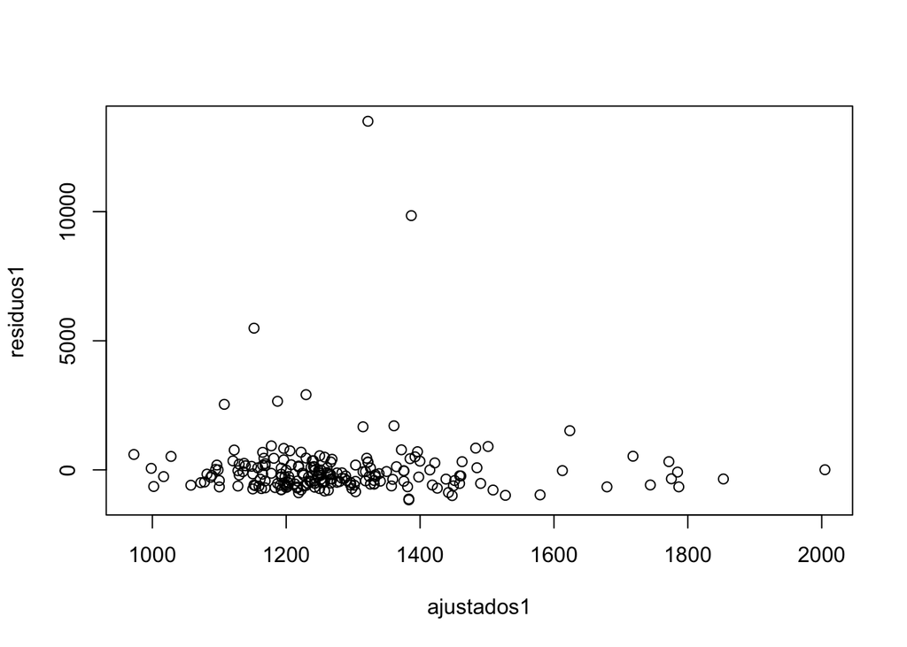

```r
#Salvando os residuos do modelo e os valores estimados
residuos1 <- regressao1$residuals
ajustados1 <- regressao1$fitted.values

# Fazendo um gráfico para verificar algum padrão
plot(ajustados1, residuos1)
```

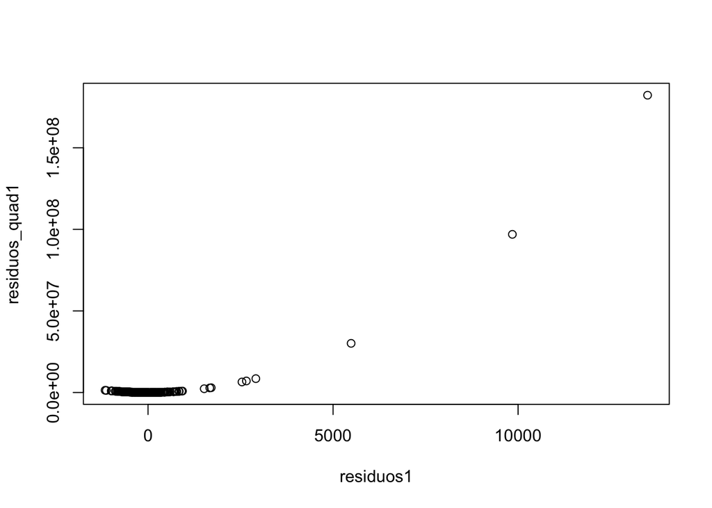

```r
# Outra possibilidade de gráfico para verificar algum padrão
residuos_quad1 = (residuos1)^2
plot(residuos1, residuos_quad1)
```

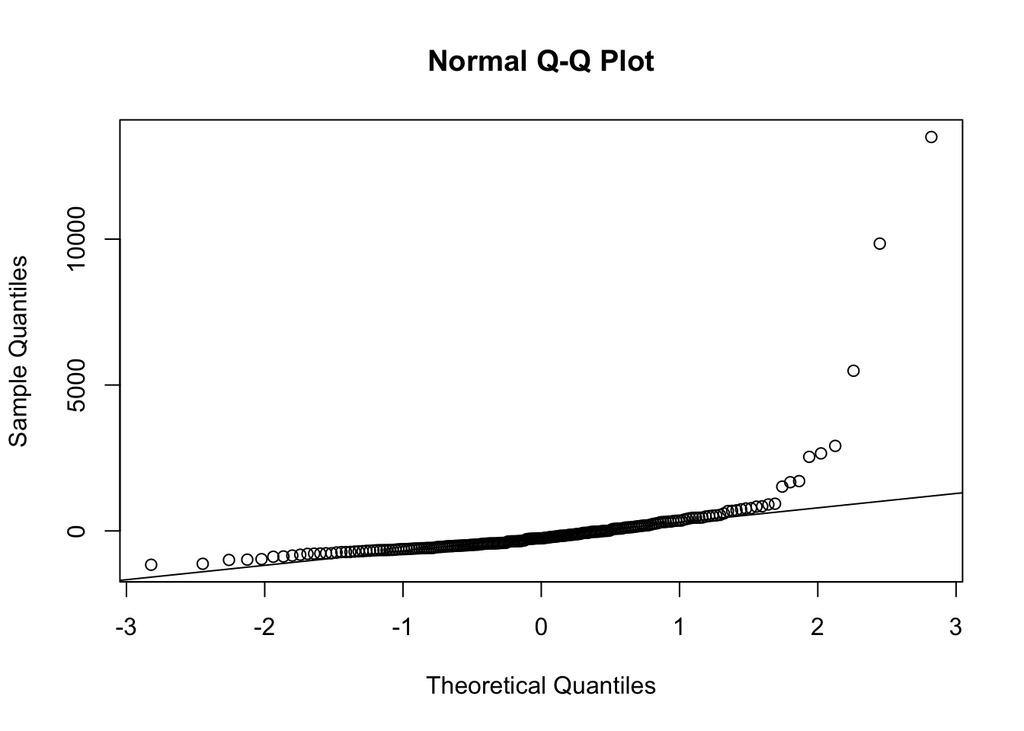

```r
#Outras análises de resíduos

#Gráfico QQ
qqnorm(residuos1)
qqline(residuos1)
```

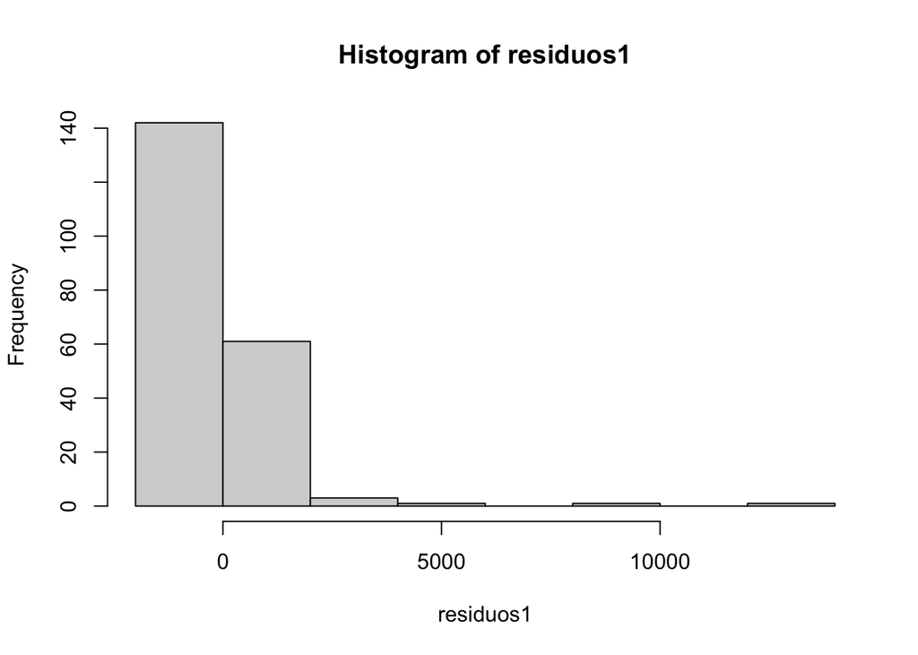

```r
hist(residuos1) #histograma dos resíduos
```